# GoMx pilot whale habitat models: Presence/absence with GAMs

### 1.2.2 Transformation of predictor variables

Below, the two sets of covariates have been combined and transformed:

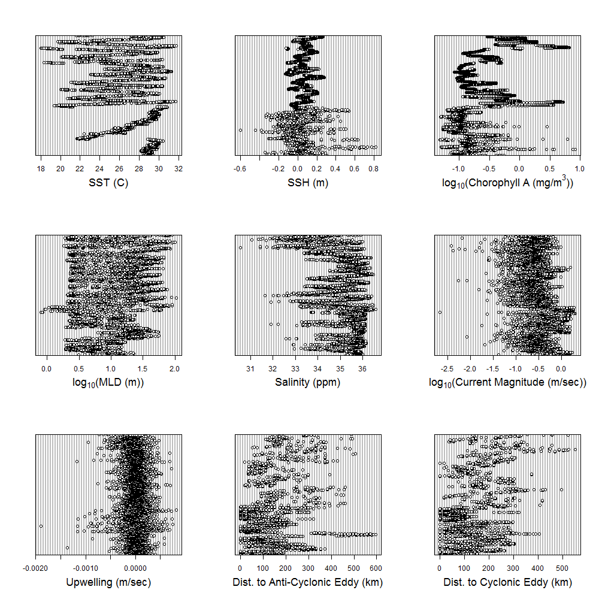

### 1.2.3 Preliminary check of predictive power

To get an idea of the basic predictive power of these covariates, we can look at presence/absence relative to each variable. This also provides an opportunity to look at the range of values observed for each covariate in the visual and acoustic datasets. In the plots below dotted lines indicate the distribution of each covariate when Kogia spp. were present, and solid lines indicate the distribution when Kogia spp. were absent. Note that these plots do not account for effort.

**Acoustic kernel densities:**

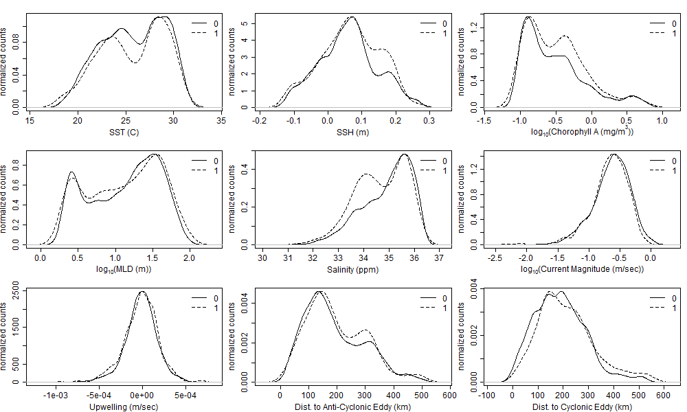

**Visual kernel densities:**

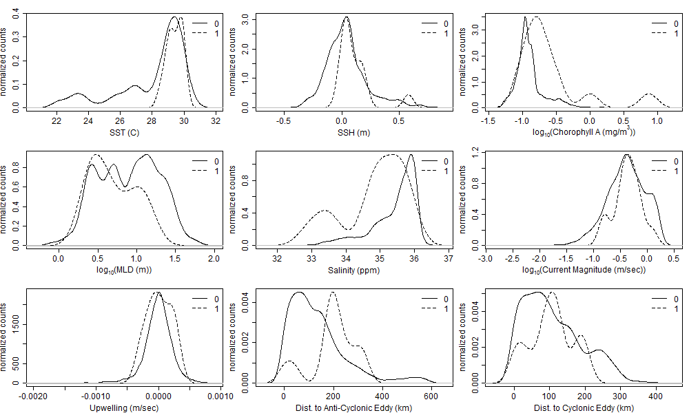

### 1.2.4 Estimation of relative weights

To train the model, we need to know how much power the various data points have relative to one another. This is important because the duration, spatial coverage, and detection probabilities are quite different between the visual and acoustic data sets. If an animal is seen or heard, we know for certain that the species was present. However, if it was not heard, then it either wasn’t present, or it was present but missed.

“Zero inflation” or an excess of false zeros more common in the visual survey data because each data point represents a 10km transect section, traversed at survey speed (>10 knots) or approximately 30 minutes of observation effort. In contrast, the acoustic data are binned by day with a stationary instrument, therefore the probability of missing a group over the course of a day is lower.

For each data type, we estimated the probability of a missed detection to account for differences in zero-inflation, downweighting zeros according to the probability of a recording false negative.

The visual data represent wether or not Kogia spp. were seen during each transect segment. The probability of missing a sighting of Kogia spp. was estimated as

$$P_{V}(detect|present) = \mu_{det} * g0\ = 0.66 * 0.66 = 0.44$$

where _{det} is the mean detection probability as estimated by a model fit using the mrds package, and g0 is the probability of observing an animal on the transect line [2]. We assume that reported absences are likely to be true absences 44 % of the time, therefore zeros are given a weight of 0.44 on a scale of [0,1].

Therefore we assume that there are no false negative days in the passive acoustic timeseries, and all acoustic observations are given weight = 1.

**Best visual detection probability model for Kogia spp.:**

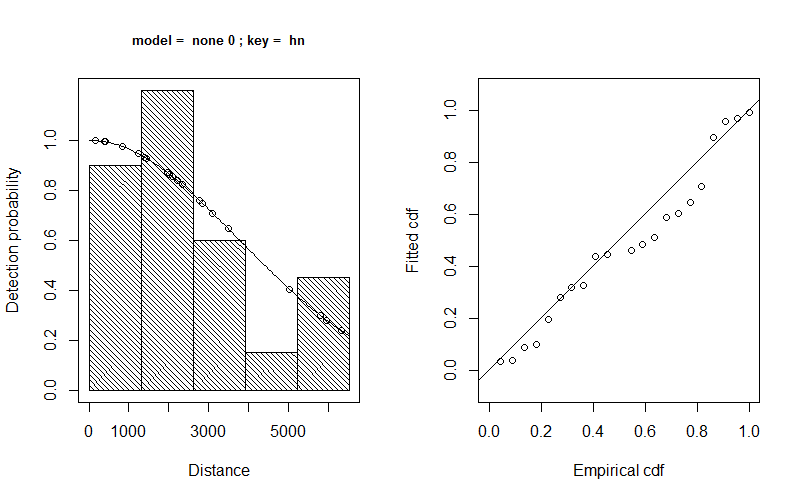

# 2. Model Fitting

Models were fit using gam from the mgcv package in R [4].

## 2.1 Set up weighting

## 2.2 Run GAMs

Run binomial GAMs on acoustic-only, visual-only, and joint acoustic/visual datasets.

```r
varNames <- names(transformedCovars_AcOnly.train)
varNamesFormula <- varNames[2:10]
formulaAcOnly_allVars <-paste('s(', varNamesFormula, ", bs = 'ts', k = kVal)", sep = "", collapse = ' + ')
formulaAcOnly_allVars <- as.formula(paste('yAcOnly_TF ~',formulaAcOnly_allVars))
gam_full_AcOnly <- gam(formulaAcOnly_allVars,
                               data = transformedCovars_AcOnly.train,
                               na.action = na.omit,family = binomial())
```

```r
formulaVisOnly_allVars <-paste('s(', varNamesFormula, ", bs = 'ts', k = kVal)", sep = "", collapse = ' + ')
formulaVisOnly_allVars <- as.formula(paste('yVisOnly_TF ~',formulaVisOnly_allVars))
gam_full_VisOnly <- gam(formulaVisOnly_allVars,
                               data = transformedCovars_VisOnly.train,
                               na.action = na.omit,family = binomial(),
                               weights = VisOnly.train_weightsG0)
```

```r
formulaJoint_allVars <-paste('s(', varNamesFormula, ", bs = 'ts', k = kVal)", sep = "", collapse = ' + ')
formulaJoint_allVars <- as.formula(paste('y_TF ~',formulaJoint_allVars))
gam_full_Joint <- gam(formulaJoint_allVars,
                        data = transformedCovars.train,
                        weights = joint_train_weightsG0,
                        na.action = na.omit,family = binomial())
```

# 3. Model Summaries

## 3.1 Acoustic-only model

Model summary:

```
##
## Family: binomial
## Link function: logit
##
## Formula:
## yAcOnly_TF ~ s(SST, bs = "ts", k = kVal) + s(log10_CHL, bs = "ts",
##     k = kVal) + s(HYCOM_SALIN_0, bs = "ts", k = kVal) + s(Pos_EddyDist,
##     bs = "ts", k = kVal)
##
## Parametric coefficients:
##             Estimate Std. Error z value Pr(>|z|)
## (Intercept) -1.71594    0.05283  -32.48   <2e-16 ***
## ---
## Signif. codes:  0 '***' 0.001 '**' 0.01 '*' 0.05 '.' 0.1 ' ' 1
##
## Approximate significance of smooth terms:
##                     edf Ref.df Chi.sq  p-value
## s(SST)           1.0325      4 15.042 4.20e-05 ***
## s(log10_CHL)     0.9656      4  6.067  0.00872 **
## s(HYCOM_SALIN_0) 2.8474      4 39.507 4.63e-10 ***
## s(Pos_EddyDist)  3.0460      4 22.810 1.52e-05 ***
## ---
## Signif. codes:  0 '***' 0.001 '**' 0.01 '*' 0.05 '.' 0.1 ' ' 1
##
## R-sq.(adj) =  0.0214   Deviance explained = 2.79%
## UBRE = -0.14115  Scale est. = 1         n = 2918
```

Smooths of predictor variables:

[figure not shown]

Plot of residuals:

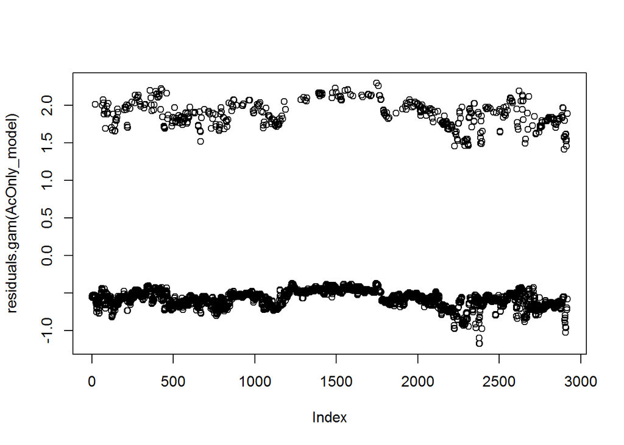

## 3.2 Visual-only model

Model summary:

```
##
## Family: binomial
## Link function: logit
##
## Formula:
## yVisOnly_TF ~ s(SST, bs = "ts", k = kVal) + s(log10_CHL, bs = "ts",
##     k = kVal) + s(Neg_EddyDist, bs = "ts", k = kVal)
##
## Parametric coefficients:
##             Estimate Std. Error z value Pr(>|z|)
## (Intercept)  -4.9830     0.5078  -9.812   <2e-16 ***
## ---
## Signif. codes:  0 '***' 0.001 '**' 0.01 '*' 0.05 '.' 0.1 ' ' 1
##
## Approximate significance of smooth terms:
##                    edf Ref.df Chi.sq p-value
## s(SST)          0.9495      4  5.809 0.01089 *
## s(log10_CHL)    0.7511      4  4.736 0.00939 **
## s(Neg_EddyDist) 0.7173      4  3.498 0.02210 *
## ---
## Signif. codes:  0 '***' 0.001 '**' 0.01 '*' 0.05 '.' 0.1 ' ' 1
##
## R-sq.(adj) =  0.0558   Deviance explained = 16.6%
## UBRE = -0.93995  Scale est. = 1         n = 1956
```

Smooths of predictor variables:

[figure not shown]

Plot of residuals:

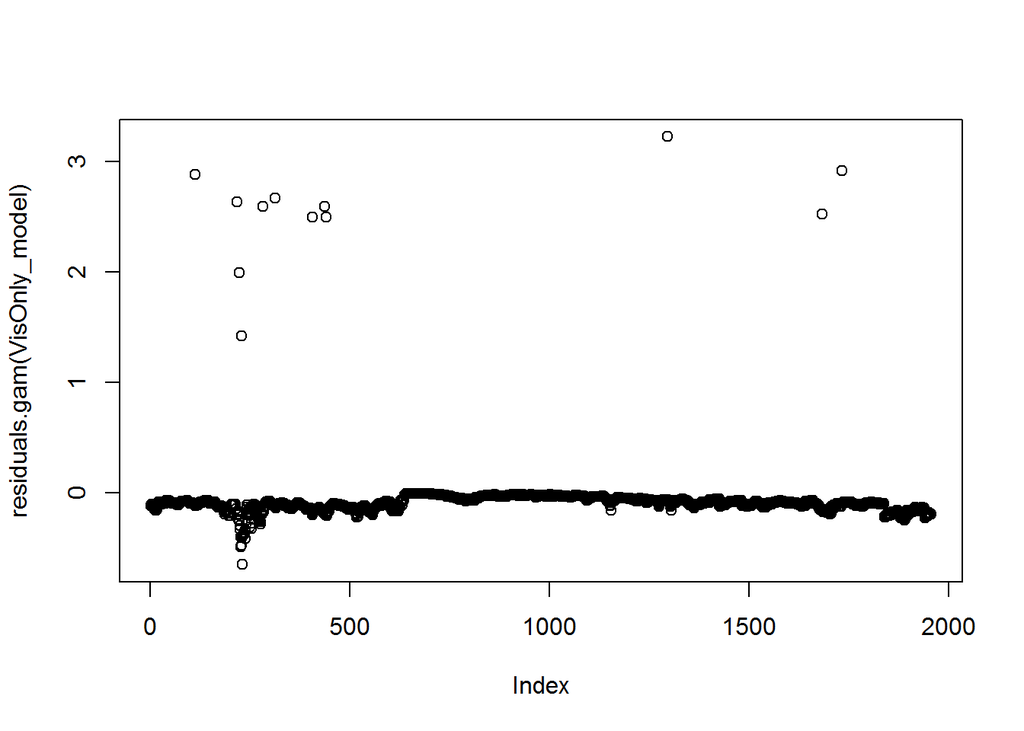

## 3.3 Joint model

Model summary:

```
##
## Family: binomial
## Link function: logit
##
## Formula:
## y_TF ~ s(SST, bs = "ts", k = kVal) + s(SSH, bs = "ts", k = kVal) +
##     s(HYCOM_SALIN_0, bs = "ts", k = kVal) + s(log10_HYCOM_MAG_0,
##     bs = "ts", k = kVal) + s(Pos_EddyDist, bs = "ts", k = kVal)
##
## Parametric coefficients:
##             Estimate Std. Error z value Pr(>|z|)
## (Intercept) -2.48040    0.08912  -27.83   <2e-16 ***
## ---
## Signif. codes:  0 '***' 0.001 '**' 0.01 '*' 0.05 '.' 0.1 ' ' 1
##
## Approximate significance of smooth terms:
##                        edf Ref.df Chi.sq  p-value
## s(SST)               1.413      4 33.162 2.63e-09 ***
## s(SSH)               2.198      4 19.084 1.92e-05 ***
## s(HYCOM_SALIN_0)     2.222      4 36.190 1.02e-09 ***
## s(log10_HYCOM_MAG_0) 2.686      4  8.409 0.019979 *
## s(Pos_EddyDist)      3.476      4 18.248 0.000346 ***
## ---
## Signif. codes:  0 '***' 0.001 '**' 0.01 '*' 0.05 '.' 0.1 ' ' 1
##
## R-sq.(adj) =  0.0526   Deviance explained = 8.89%
## UBRE = -0.65509  Scale est. = 1         n = 4935
```

Smooths of predictor variables:

[figure not shown]

Plot of residuals:

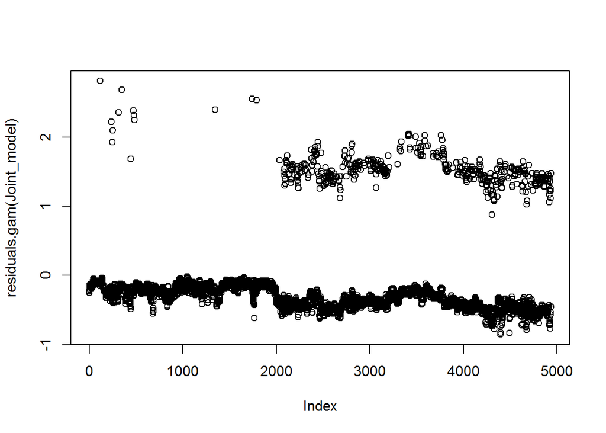

## 3.4 Model prediction on joint dataset

```
## [1] "cross entropy scores (lower is better)"
```

```
##                            Cross-Entropy Score
## Acoustic - Test Joint Data               5.327
## Visual - Test Joint Data                 5.327
## Joint - Test Joint Data                  5.308
```

# 4. Model Predictions

## 4.1 Temporal predictions

### 4.1.1 Acoustic-only prediction

**Predicted and observed encounter probabilities at passive acoustic monitoring sites using the acoustic-only model:**

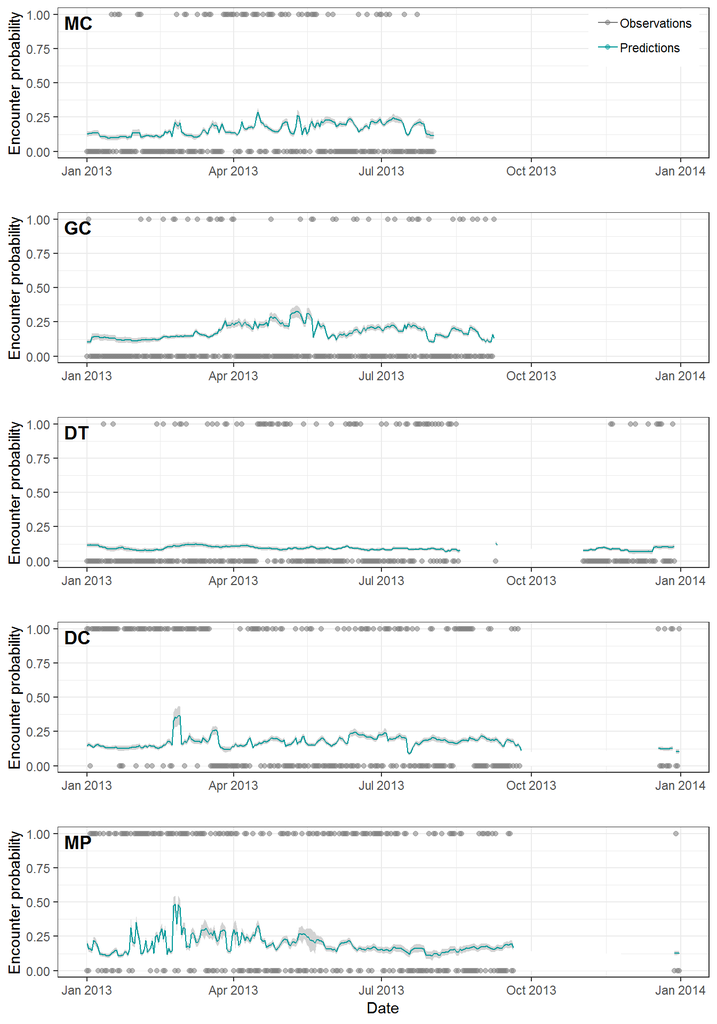

### 4.1.2 Visual-only prediction

**Predicted and observed encounter probabilities at passive acoustic monitoring sites using the visual-only model:**

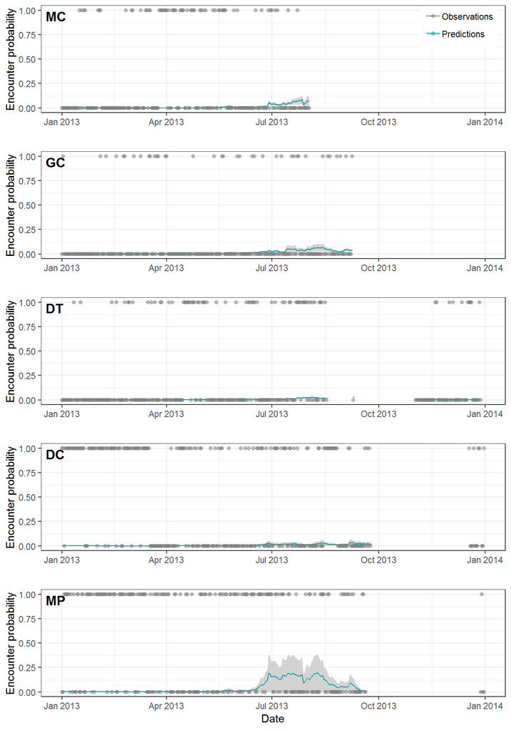

### 4.1.3 Joint prediction

**Predicted and observed encounter probabilities at passive acoustic monitoring sites using the joint model:**

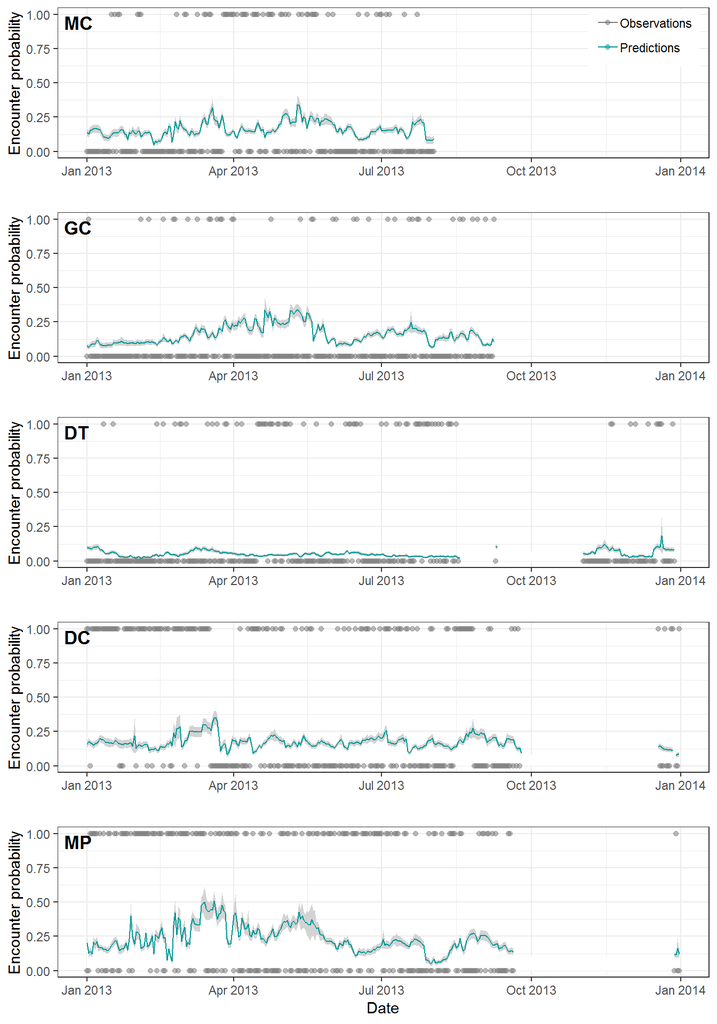

## 4.2 Spatial predictions

Models were evaluated for summer (July 2009) and winter(January 2009) across the entire Gulf of Mexico (US EEZ beyond the 200m contour).

Note: As an alternative to training joint models, an average surface was computed across the acoustic and visual-only predictions.

**Summer 2009 predicted distribution and test sightings:**

[interactive chart not shown]

**Winter 2009 predicted distribution:**

[interactive chart not shown]

# 5. Monthly model predictions

Spatial model predictions were generated using climatological means of oceanographic variables, averaged by month between 2003 and 2015.

[interactive chart not shown]

# References

1. Frasier KE, Wiggins SM, Harris D, Marques TA, Thomas L, Hildebrand JA. Delphinid echolocation click detection probability on near-seafloor sensors. The Journal of the Acoustical Society of America. 2016;140: 1918–1930. doi:http://dx.doi.org/10.1121/1.4962279

2. Palka DL. Summer abundance estimates of cetaceans in us north atlantic navy operating areas. Northeast Fish Sci Cent Ref Doc. 2006; 06–03.

3. Hildebrand J, Baumann-Pickering S, Frasier K, Tricky J, Merkens K, Wiggins S, et al. Passive acoustic monitoring of beaked whale densities in the gulf of mexico during and after the deepwater horizon oil spill. Nature Scientific Reports. 2015;5: 16343.

4. Wood S. Generalized additive models: An introduction with r. CRC press; 2006.